# Fusariose: use of expression data

# 1/ Introduction

This file is a supplementary data attached with the publication. It aims to describe the expression data of the Fusariose project Let’s upload: - The file with the expression of each gene, for every individuals - The genotype matrix

```r
#Watch out, to reproduct analysis, you have to update the path.

#Expression
data <- read.delim("~/Dropbox/Publi_Fusariose/ANALYSIS_REPRO/DATA/Expression.txt")
rownames(data)=data[,1]
data=data[,-1]
colnames(data)=gsub("DC", "TT06DC." , colnames(data))
rownames(data)=gsub("\\|T.*","",rownames(data) )

# Genotype matrix
geno = read.table(file="~/Dropbox/Publi_Fusariose/ANALYSIS_REPRO/DATA/fichier_genotypage_QTL.csv", sep = ";" , header = F, na.strings = "-")
geno= as.matrix(geno)
colnames(geno)= geno[1,]
geno= as.data.frame(geno[-1 , ])
# Remove useless individuals
geno <- geno [ geno[,1] %in% names(data),]

# Position of genes
POS=read.table("~/Dropbox/Publi_Fusariose/ANALYSIS_REPRO/DATA/physical_map_of_BW.txt", header=T)
POS$position=POS$position/1000000

# Annotation
ANOT=read.table("~/Dropbox/Publi_Fusariose/ANALYSIS_REPRO/DATA/mart_export_Annotation.txt", sep="\t", header=T)
```

Charge some libraries that will be useful

```r
library(RColorBrewer)
library(xtable)
library(plotly)
library(FactoMineR)
library(DESeq2)
```

Let’s create a color vector for the study

```r
my_colors = brewer.pal(8, "Set2")
my_colors = colorRampPalette(my_colors)(15)
```

## 2/ Usefull function

```r
# A function to represent a DE genes. It makes a boxplot with 2 categories: alleles A and B
boxplot_DE_genes=function(marker, expr_gene){

  # prepare data: merge expression and alleles:
  nucl= geno[,c(1,which(colnames(geno)==marker)) ]
  expr= t(data[which(rownames(data)==expr_gene) , ])
  expr=data.frame(ind=rownames(expr), expr[,1] )
  AA=merge(expr, nucl, by.x=1, by.y=1, all=T)

  # Compute means
  my_means=aggregate(AA[,2] , by=list(AA[,3]), mean, na.rm=T)
  my_meanA=round(my_means[1,2] , 2)
  my_meanB=round(my_means[2,2] , 2)
  # T test
  my_ttest=round(t.test(AA[,2]~AA[,3])$p.value , 2)

  # Basic boxplot
  boxplot(AA[,2]~AA[,3],
        col=my_colors[c(5,6)],
        ylab=paste("expression of ",gsub("\\|T.*","",expr_gene),sep=""),
        xlab=paste("allele of ",marker,sep="") ,
        main=paste("A: ",my_meanA," | B: ",my_meanB," | pval: ",my_ttest, sep="" )
        )

  # Add data points
  mylevels<-levels(AA[,3])
  levelProportions<-summary(AA[,3])/nrow(AA)
  for(i in 1:length(mylevels)){
    thislevel<-mylevels[i]
    thisvalues<-AA[AA[,3]==thislevel, 2]
    # take the x-axis indices and add a jitter, proportional to the N in each level
    myjitter<-jitter(rep(i, length(thisvalues)), amount=levelProportions[i]/2)
    points(myjitter, thisvalues, pch=20, col=rgb(0,0,0,.2))
  }
}

#Let's create a function that does the DE genes analysis for a given marker.
get_DE_genes=function( marker ){

  # TMP On ne prend que les n premières lignes de data
  don=data
  #don<-head(data,n=100)

  # sum_expe contains the marker of interest
  sum_expe=data.frame(
    geno=c(as.character(geno[,1]),"dic2","silur"),
    marker=c(as.character(geno[,which(colnames(geno)==marker) ]) , "A", "B")
  )
  sum_expe=na.omit(sum_expe)

  # in data, I keep only individuals genotyped for the marker
  don=don[ , which(colnames(don)%in%sum_expe[,1]) ]

  # reorder sum_expe
  sum_expe=sum_expe[match(colnames(don),sum_expe[,1] ), ]
  rownames(sum_expe)=sum_expe[,1]

  # Call DeSeq2
  dds <- DESeqDataSetFromMatrix(don, sum_expe, formula( ~ marker))
  dds <- DESeq(dds)
  res <- results(dds,contrast=c("marker","A","B") )
  return(res)

  # close function
  }
```

# 3/ Description of the expression file

How many genes and individuals?

```r
n_gene=nrow(data)
n_indiv=ncol(data)-1
```

Let’s have a look to the distribution of the number of reads per sample:

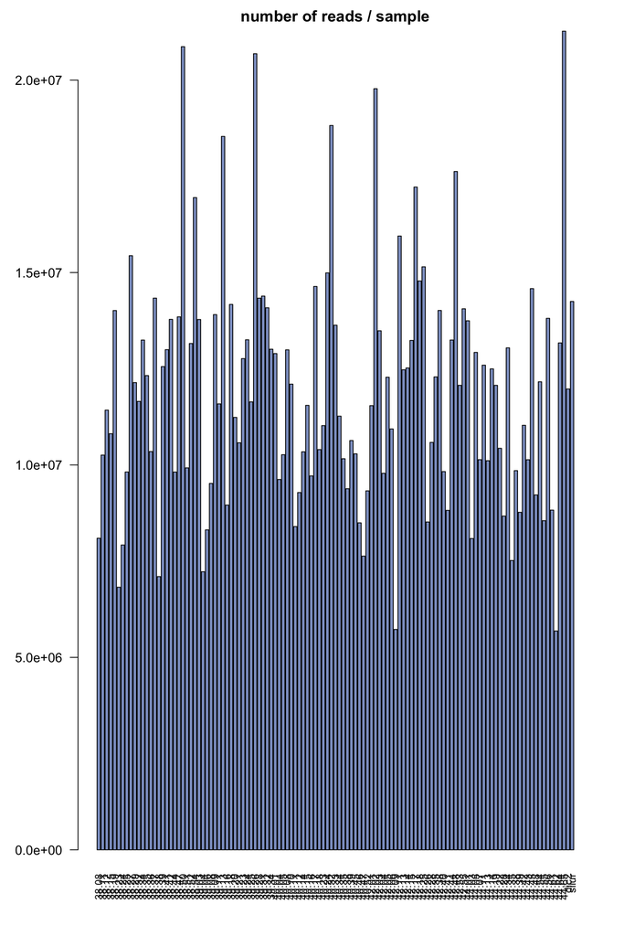

```r
# Calul du nbr de reads
tot_reads_number=apply(data[,-1] , 2 , sum)
names(tot_reads_number)=gsub("TT06DC.","",names(tot_reads_number))
par(mar=c(5,5,2,2), mfrow=c(1,1))
barplot( tot_reads_number , col=my_colors[5] , las=2, main="number of reads / sample", cex.names=0.8)
```

Distribution of the number of reads / gene for 4 random samples:

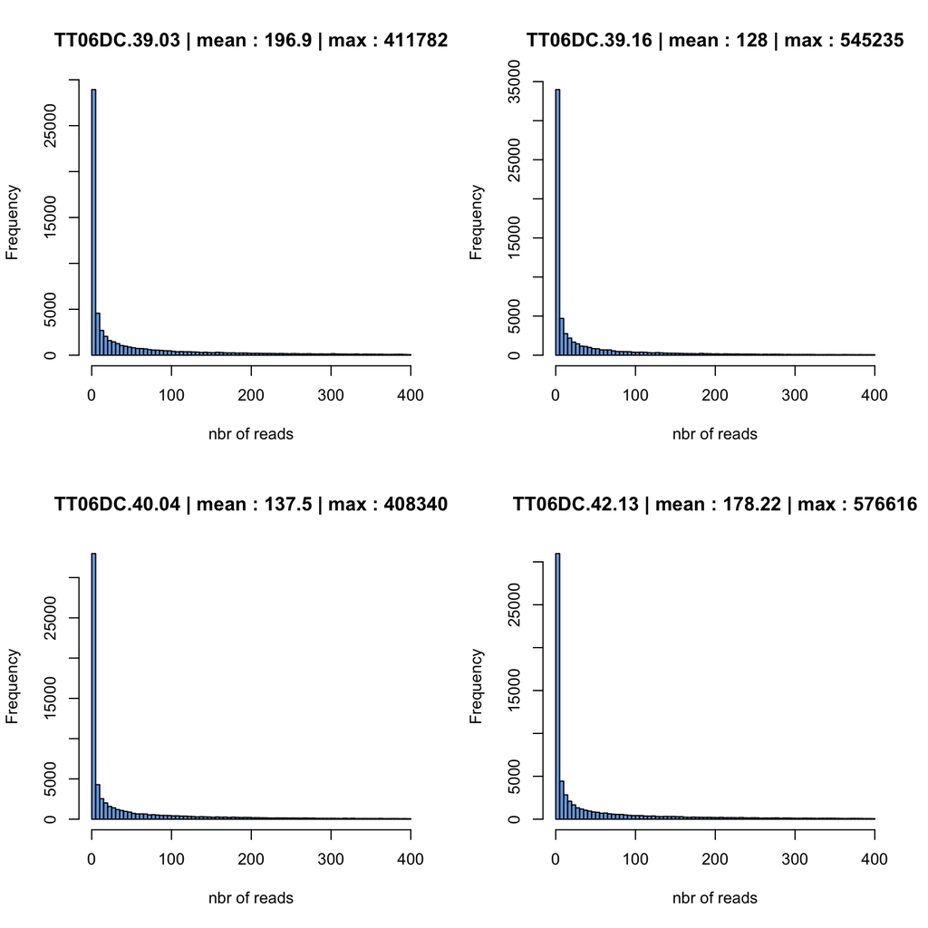

```r
set.seed(345)
sub=data[ , sample(2:120 , 4)]
par(mfrow=c(2,2)) ; for(i in 1:4){hist(sub[,i][sub[,i]<400] , breaks=100 , main=paste(colnames(sub)[i] , " | mean : ", round(mean(sub[,i]),2), " | max : "  , max(sub[,i]), sep="")  , xlab="nbr of reads" , col=rgb(0.2,0.5,0.8,0.7) )  }
```

As usual on a RNA-Seq experiment, we oberve a lot of genes with low expression (0-100 reads), and a few genes highly expressed (until 600 000 reads!)

# 4/ Get Differentially Expressed genes (DE)

During the QTL analysis, we detected markers that are involved in the resistance to Fusarium. It would be interesting to check if we can discover genes that are differentially expressed between individuals with the resistant allele (A) and the sensitive allele (B).

We have 2 main QTLs on chromosome 1B and 5A. We can apply this function 2 times, one for each QTL. For each QTL we take the marker the most representative of the zone.

```r
# Threshold of detection:
thres=0.05

#Get the DE for the 1B QTL
marker_1B="Traes_1BS_B9CBEFAE5@3469"
DE_genes_QTL_1B=get_DE_genes(marker_1B)
```

```
## -- replacing outliers and refitting for 1130 genes
## -- DESeq argument 'minReplicatesForReplace' = 7
## -- original counts are preserved in counts(dds)
```

```r
#Get the DE for the 5A QTL
marker_5A="Traes_5AL_7102B2151@946"
DE_genes_QTL_5A=get_DE_genes(marker_5A)
```

```
## -- replacing outliers and refitting for 1077 genes
## -- DESeq argument 'minReplicatesForReplace' = 7
## -- original counts are preserved in counts(dds)
```

Let’s have a look to the distribution of pval adjusted in the 2 cases.  
We are supposed to have a “L” distribution if we want to get DE genes considering adjusted pvalue (False Discovery Rate).  
We can see that it is the case for the 1B QTL,but not really for the 5A. So we will probably have only few DE genes for the 5B.

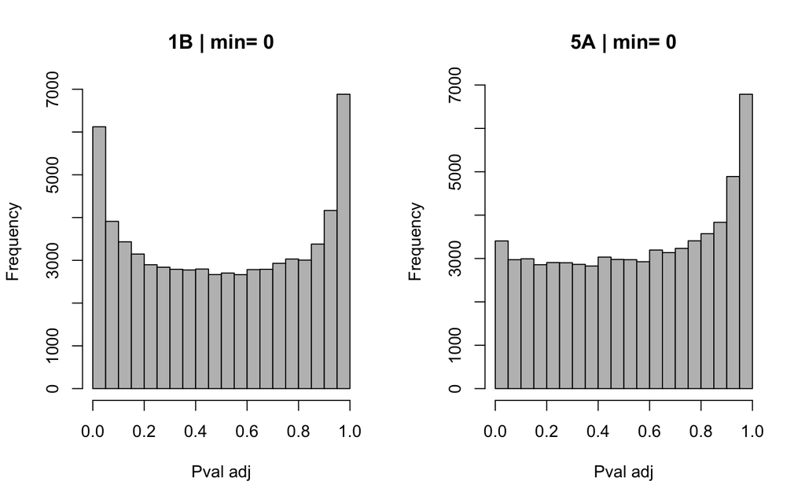

```r
par(mfrow=c(1,2))
hist(DE_genes_QTL_1B$pvalue , main=paste("1B | min= ",round(min(DE_genes_QTL_1B$padj, na.rm=T),2),sep="") , col="grey" , xlab="Pval adj")
hist(DE_genes_QTL_5A$pvalue , main=paste("5A | min= ",round(min(DE_genes_QTL_5A$padj, na.rm=T),2),sep="") , col="grey" , xlab="Pval adj")
```

Let’s have a look to the most DE genes for the 1B QTL.

```r
a=DE_genes_QTL_1B[ order(DE_genes_QTL_1B$padj) , ]
head(a,2)
```

```
## log2 fold change (MAP): marker A vs B
## Wald test p-value: marker A vs B
## DataFrame with 2 rows and 6 columns
##                      baseMean log2FoldChange     lfcSE      stat
##                     <numeric>      <numeric> <numeric> <numeric>
## Traes_2AL_89E21DB6D  3252.041      -3.675204 0.1155924 -31.79452
## Traes_5AL_23EFF34D0  1806.674      -3.345937 0.1107865 -30.20166
##                            pvalue          padj
##                         <numeric>     <numeric>
## Traes_2AL_89E21DB6D 7.707317e-222 3.602554e-217
## Traes_5AL_23EFF34D0 2.252783e-200 5.264980e-196
```

```r
a=DE_genes_QTL_5A[ order(DE_genes_QTL_5A$padj) , ]
head(a,2)
```

```
## log2 fold change (MAP): marker A vs B
## Wald test p-value: marker A vs B
## DataFrame with 2 rows and 6 columns
##                      baseMean log2FoldChange      lfcSE      stat
##                     <numeric>      <numeric>  <numeric> <numeric>
## Traes_5AL_D8DC40ABF 212.59043      -1.625855 0.07351936 -22.11466
## Traes_5AL_A1C6F9E51  81.32976       1.791343 0.10754335  16.65694
##                            pvalue          padj
##                         <numeric>     <numeric>
## Traes_5AL_D8DC40ABF 2.284336e-108 1.426568e-103
## Traes_5AL_A1C6F9E51  2.694805e-62  8.414527e-58
```

The boxplot of the most DE genes related to the QTL 1B and 5A to check how big is the difference

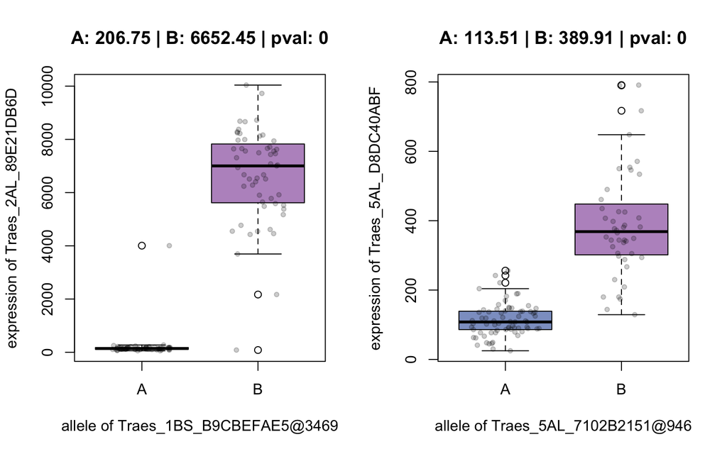

```r
# use function
par(mfrow=c(1,2))
boxplot_DE_genes(marker_1B, "Traes_2AL_89E21DB6D" )
boxplot_DE_genes(marker_5A, "Traes_5AL_D8DC40ABF" )
```

```r
# huge difference. So the script looks all right!
```

Let’s get the significant DE genes for the 2 QTLs. I merge this information with the physical positions and the annotation data provided by Ensembl Plant.

```r
#1B
res_sig_1B=as.data.frame( DE_genes_QTL_1B[ which(DE_genes_QTL_1B$padj<thres) , ] )
res_sig_1B=merge(res_sig_1B, POS, by.x="row.names", by.y=2, all.x=T)
res_sig_1B=merge(res_sig_1B, ANOT, by.x=1, by.y=1, all.x=T)
#5A
res_sig_5A=data.frame( DE_genes_QTL_5A[ which(DE_genes_QTL_5A$padj<thres) , ] )
res_sig_5A=merge(res_sig_5A, POS, by.x="row.names", by.y=2, all.x=T)
res_sig_5A=merge(res_sig_5A, ANOT, by.x=1, by.y=1, all.x=T)
```

# 5/ DE-viz for 1B

How many DE genes do we have?

```r
nrow(res_sig_1B)
```

```
## [1] 323
```

On which chromosome are these DE genes?

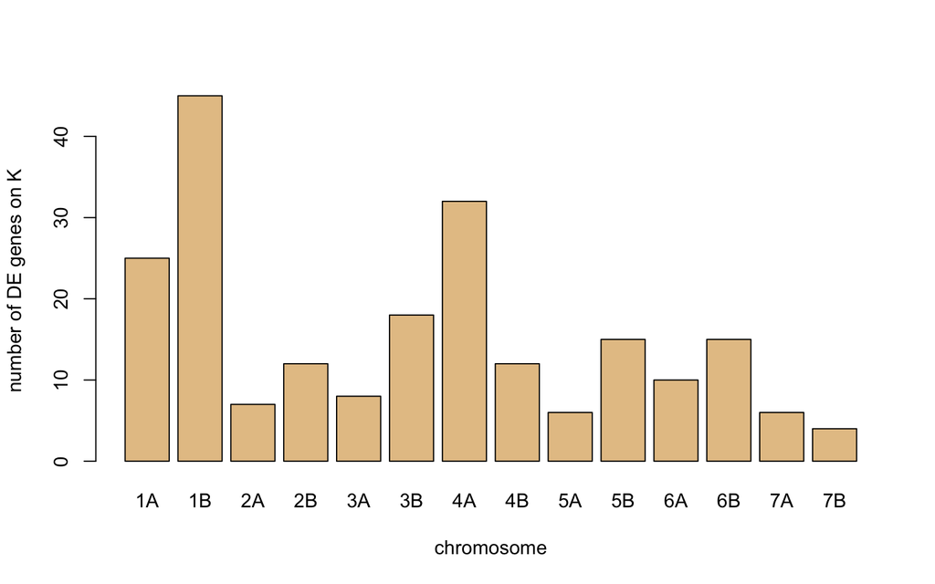

```r
a=table(res_sig_1B$group)
a=a[a!=0]
par(mfrow=c(1,1))
barplot(a, col=my_colors[13], ylab="number of DE genes on K", xlab="chromosome")
```

```r
# Nbr
a["1B"]
```

```
## 1B
## 45
```

```r
# Percentage in %
round( a["1B"]/sum(a)*100 , 2)
```

```
##    1B
## 20.93
```

Representation on the chromosome 1B? Each blue point represent a DE gene. The pink zone is the IC of the QTL 1B. The Y axis gives the Log2Foldchange: it is the lof of the difference of expression between alleles A and B.

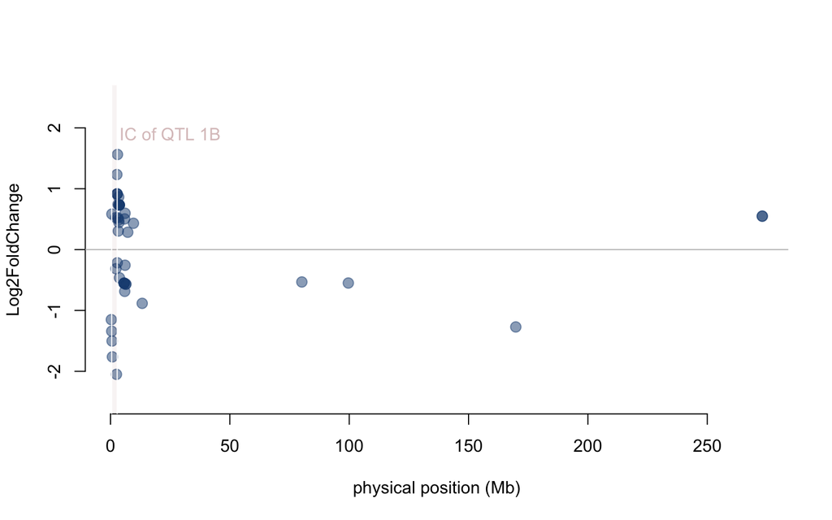

```r
AA=res_sig_1B[which(res_sig_1B$group=="1B"), ]
plot(AA$log2FoldChange ~ AA$position, bty="n", ylim=c(-2.5, 2.5) , xlab="physical position (Mb)", ylab="Log2FoldChange", pch=20, cex=2, col=rgb(0.1,0.3,0.5,0.5))
abline(h=0, col="grey")
rect(0.5,-4,2.8,4, col=rgb(0.5,0.1,0.1,0.05), border=F)
text(25,1.9,"IC of QTL 1B" , col=rgb(0.5,0.1,0.1,0.3))
```

How many genes are known to be in this IC in total?

```r
interesting_pos=POS[ which(POS$group=="1B" & POS$position>0.5 & POS$position<2.8) , ]
nrow(interesting_pos)
```

```
## [1] 43
```

Let’s represent all these genes with a grey line. Then, we show the DE genes with a blue point.

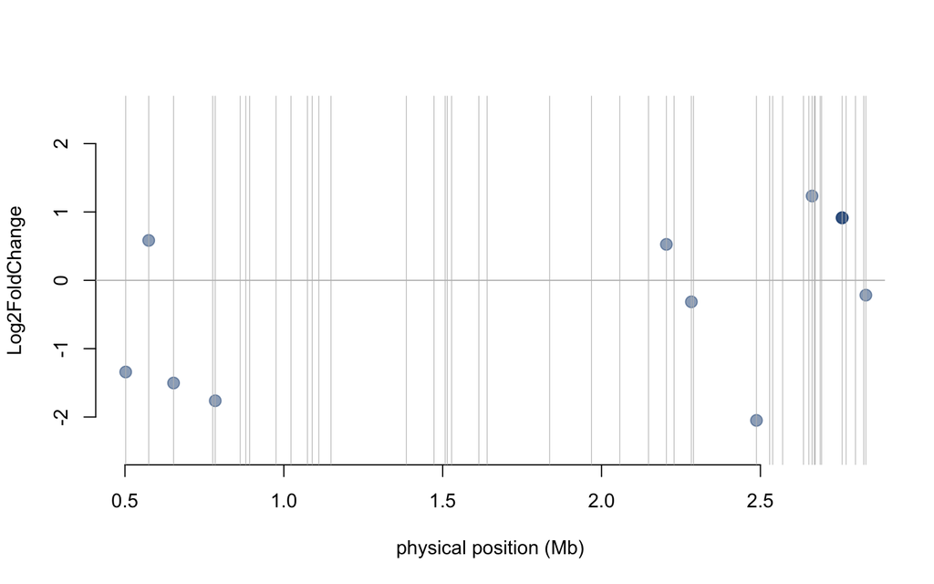

```r
plot(AA$log2FoldChange ~ AA$position, bty="n", ylim=c(-2.5, 2.5) , xlab="physical position (Mb)", ylab="Log2FoldChange", pch=20, cex=2, col=rgb(0.1,0.3,0.5,0.5), xlim=c(0.5,2.8))
abline(h=0, col="grey")
abline(v=POS[which(POS$group=="1B") , 3] , col="grey", lwd=0.6)
```

Now, let’s have a look to the annotation of the DE genes?

| Row.names | group | position | Transcript.stable.ID | GO.term.accession | GO.term.name | GO.term.evidence.code | GO.domain |
| --- | --- | --- | --- | --- | --- | --- | --- |
| Traes_1BL_A58B7DF14 | 1B | 273.05 | Traes_1BL_A58B7DF14.2 | GO:0005515 | protein binding | IEA | molecular_function |
| Traes_1BL_A58B7DF14 | 1B | 273.05 | Traes_1BL_A58B7DF14.2 | GO:0043531 | ADP binding | IEA | molecular_function |
| Traes_1BS_17F50CC8B | 1B | 2.49 | Traes_1BS_17F50CC8B.1 |  |  |  |  |
| Traes_1BS_268BDC54E | 1B | 3.52 | Traes_1BS_268BDC54E.1 |  |  |  |  |
| Traes_1BS_37426DBD4 | 1B | 3.66 | Traes_1BS_37426DBD4.1 | GO:0016772 | transferase activity, transferring phosphorus-containing groups | IEA | molecular_function |
| Traes_1BS_37426DBD4 | 1B | 3.66 | Traes_1BS_37426DBD4.1 | GO:0048544 | recognition of pollen | IEA | biological_process |
| Traes_1BS_37426DBD4 | 1B | 3.66 | Traes_1BS_37426DBD4.1 | GO:0004674 | protein serine/threonine kinase activity | IEA | molecular_function |
| Traes_1BS_37426DBD4 | 1B | 3.66 | Traes_1BS_37426DBD4.1 | GO:0006468 | protein phosphorylation | IEA | biological_process |
| Traes_1BS_37426DBD4 | 1B | 3.66 | Traes_1BS_37426DBD4.1 | GO:0004672 | protein kinase activity | IEA | molecular_function |
| Traes_1BS_37426DBD4 | 1B | 3.66 | Traes_1BS_37426DBD4.1 | GO:0005524 | ATP binding | IEA | molecular_function |
| Traes_1BS_3F0960880 | 1B | 7.23 | Traes_1BS_3F0960880.1 |  |  |  |  |
| Traes_1BS_479628E92 | 1B | 3.43 | Traes_1BS_479628E92.1 |  |  |  |  |
| Traes_1BS_6081AAC0A | 1B | 2.76 | Traes_1BS_6081AAC0A.1 | GO:0008171 | O-methyltransferase activity | IEA | molecular_function |
| Traes_1BS_6081AAC0A | 1B | 2.76 | Traes_1BS_6081AAC0A.1 | GO:0046983 | protein dimerization activity | IEA | molecular_function |
| Traes_1BS_6081AAC0A | 1B | 2.76 | Traes_1BS_6081AAC0A.1 | GO:0008168 | methyltransferase activity | IEA | molecular_function |
| Traes_1BS_D27F3336C | 1B | 5.73 | Traes_1BS_D27F3336C.1 | GO:0005840 | ribosome | IEA | cellular_component |
| Traes_1BS_D27F3336C | 1B | 5.73 | Traes_1BS_D27F3336C.1 | GO:0015934 | large ribosomal subunit | IEA | cellular_component |
| Traes_1BS_D27F3336C | 1B | 5.73 | Traes_1BS_D27F3336C.1 | GO:0003735 | structural constituent of ribosome | IEA | molecular_function |
| Traes_1BS_D27F3336C | 1B | 5.73 | Traes_1BS_D27F3336C.1 | GO:0006412 | translation | IEA | biological_process |